# RNAseq Analysis of E12 Polr1a; Foxg1<sup>Cre/+</sup>

Weaver Lab

2022-06-21

## 0.1 Introduction

This reproducible and dynamic report was created using Rmarkdown and the [Knitr package](https://yihui.name/knitr/), and displays code and outputs produced during analysis. This report was created following the [DIYtranscriptomics](https://journals.asm.org/doi/10.1128/mBio.01214-21) pipeline.

## 0.2 R packages used

A variety of R packages was used for this analysis. All packages used are listed at the end of this report under Session Info. All packages used are available from the Comprehensive R Archive Network (CRAN), Bioconductor, or Github.

## 0.3 Read mapping

### 0.3.1 Aligning raw reads with Kallisto

Raw reads were mapped to the mouse reference transcriptome using [Kallisto](https://pachterlab.github.io/kallisto/), version 0.46.2. Quality control of raw reads, as well as the results of Kallisto mapping are summarized in this [multiqc summary report](https://github.com/kascchmc/symmetrical-parakeet/blob/main/multiqc_report.html) generated using [fastqc](https://www.bioinformatics.babraham.ac.uk/projects/fastqc/) and [multiqc](https://multiqc.info/).

### 0.3.2 Importing count data into R

After read mapping with Kallisto, [TxImport](https://bioconductor.org/packages/release/bioc/html/tximport.html) was used to read kallisto outputs into the R environment. Annotation data from Biomart was used to summarize data from transcript-level to gene-level.

```r
library(tidyverse) # provides access to Hadley Wickham's collection of R packages for data science, which we will use throughout the course
library(tximport) # package for getting Kallisto results into R
library(ensembldb) #helps deal with ensembl
library(EnsDb.Mmusculus.v79) #replace with your organism-specific database package
targets <- read_tsv("studydesign.txt")# read in your study design
path <- file.path(targets$sample, "abundance.tsv") # set file paths to your mapped data
Tx <- transcripts(EnsDb.Mmusculus.v79, columns=c("tx_id", "gene_name"))
Tx <- as_tibble(Tx)
Tx <- dplyr::rename(Tx, target_id = tx_id)
Tx <- dplyr::select(Tx, "target_id", "gene_name")
Txi_gene <- tximport(path,
                     type = "kallisto",
                     tx2gene = Tx,
                     txOut = FALSE, #determines whether your data represented at transcript or gene level
                     countsFromAbundance = "lengthScaledTPM",
                     ignoreTxVersion = TRUE)
```

## 0.4 Preprocessing

### 0.4.1 Impact of filtering and normalization

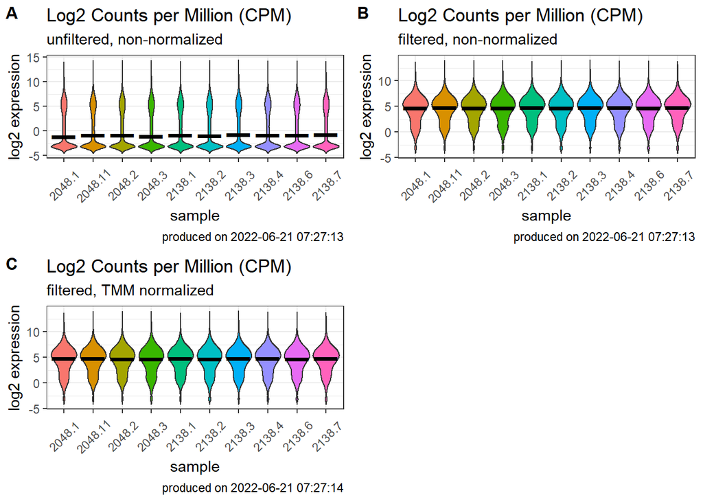

```r
library(tidyverse)
library(edgeR)
library(matrixStats)
library(cowplot)

sampleLabels <- targets$sample
myDGEList <- DGEList(Txi_gene$counts)
log2.cpm <- cpm(myDGEList, log=TRUE)

log2.cpm.df <- as_tibble(log2.cpm, rownames = "geneID")
colnames(log2.cpm.df) <- c("geneID", sampleLabels)
log2.cpm.df.pivot <- pivot_longer(log2.cpm.df, # dataframe to be pivoted
                                  cols = Polr_2048_1:Polr_2138_7, # column names to be stored as a SINGLE variable
                                  names_to = "samples", # name of that new variable (column)
                                  values_to = "expression") # name of new variable (column) storing all the values (data)

p1 <- ggplot(log2.cpm.df.pivot) +
  aes(x=samples, y=expression, fill=samples) +
  geom_violin(trim = FALSE, show.legend = FALSE) +
  stat_summary(fun = "median",
               geom = "point",
               shape = 95,
               size = 10,
               color = "black",
               show.legend = FALSE) +
  labs(y="log2 expression", x = "sample",
       title="Log2 Counts per Million (CPM)",
       subtitle="unfiltered, non-normalized",
       caption=paste0("produced on ", Sys.time())) +
  theme_bw() +
  scale_x_discrete(labels = c("2048.1", "2048.11", "2048.2", "2048.3", "2138.1", "2138.2", "2138.3", "2138.4", "2138.6", "2138.7")) +
  theme(axis.text.x = element_text(angle = 45, vjust = 0.5))

cpm <- cpm(myDGEList)
keepers <- rowSums(cpm>1)>=2 #user defined, be sure to adjust this cutoff for the number of samples in the smallest group of comparison.
myDGEList.filtered <- myDGEList[keepers,]

log2.cpm.filtered <- cpm(myDGEList.filtered, log=TRUE)
log2.cpm.filtered.df <- as_tibble(log2.cpm.filtered, rownames = "geneID")
colnames(log2.cpm.filtered.df) <- c("geneID", sampleLabels)
log2.cpm.filtered.df.pivot <- pivot_longer(log2.cpm.filtered.df, # dataframe to be pivoted
                                           cols = Polr_2048_1:Polr_2138_7, # column names to be stored as a SINGLE variable
                                           names_to = "samples", # name of that new variable (column)
                                           values_to = "expression") # name of new variable (column) storing all the values (data)

p2 <- ggplot(log2.cpm.filtered.df.pivot) +
  aes(x=samples, y=expression, fill=samples) +
  geom_violin(trim = FALSE, show.legend = FALSE) +
  stat_summary(fun = "median",
               geom = "point",
               shape = 95,
               size = 10,
               color = "black",
               show.legend = FALSE) +
  labs(y="log2 expression", x = "sample",
       title="Log2 Counts per Million (CPM)",
       subtitle="filtered, non-normalized",
       caption=paste0("produced on ", Sys.time())) +
  theme_bw() +
  scale_x_discrete(labels = c("2048.1", "2048.11", "2048.2", "2048.3", "2138.1", "2138.2", "2138.3", "2138.4", "2138.6", "2138.7")) +
  theme(axis.text.x = element_text(angle = 45, vjust = 0.5))

myDGEList.filtered.norm <- calcNormFactors(myDGEList.filtered, method = "TMM")
log2.cpm.filtered.norm <- cpm(myDGEList.filtered.norm, log=TRUE)
log2.cpm.filtered.norm.df <- as_tibble(log2.cpm.filtered.norm, rownames = "geneID")
colnames(log2.cpm.filtered.norm.df) <- c("geneID", sampleLabels)
log2.cpm.filtered.norm.df.pivot <- pivot_longer(log2.cpm.filtered.norm.df, # dataframe to be pivoted
                                                cols = Polr_2048_1:Polr_2138_7, # column names to be stored as a SINGLE variable
                                                names_to = "samples", # name of that new variable (column)
                                                values_to = "expression") # name of new variable (column) storing all the values (data)
#write.csv(log2.cpm.filtered.df.pivot, "Filtered and Normalized Expression.csv")

p3 <- ggplot(log2.cpm.filtered.norm.df.pivot) +
  aes(x=samples, y=expression, fill=samples) +
  geom_violin(trim = FALSE, show.legend = FALSE) +
  stat_summary(fun = "median",
               geom = "point",
               shape = 95,
               size = 10,
               color = "black",
               show.legend = FALSE) +
  labs(y="log2 expression", x = "sample",
       title="Log2 Counts per Million (CPM)",
       subtitle="filtered, TMM normalized",
       caption=paste0("produced on ", Sys.time())) +
  theme_bw() +
  scale_x_discrete(labels = c("2048.1", "2048.11", "2048.2", "2048.3", "2138.1", "2138.2", "2138.3", "2138.4", "2138.6", "2138.7")) +
  theme(axis.text.x = element_text(angle = 45, vjust = 0.5))

plot_grid(p1, p2, p3, labels = c('A', 'B', 'C'), label_size = 12)
```

Expressed genes with less than 1 count per million (CPM) in at least 2 or more samples were filtered out. This reduced the number of genes from 29957 to 14797. Genes were then normalized using the [TMM method](https://genomebiology.biomedcentral.com/articles/10.1186/gb-2010-11-3-r25).

### 0.4.2 table of filtered and normalized data

```r
library(tidyverse)
library(DT)
library(gt)
library(plotly)

mydata.df <- log2.cpm.filtered.norm.df %>%
  mutate(wt.AVG = (Polr_2048_1 + Polr_2048_3 + Polr_2138_1 + Polr_2138_2 + Polr_2138_4)/5,
         gt.AVG = (Polr_2048_2 + Polr_2048_11)/2,
         cf.AVG = (Polr_2138_3 + Polr_2138_6 + Polr_2138_7)/3,
         #now make columns comparing each of the averages above that you're interested in
         NullLogFC = (gt.AVG - wt.AVG),
         C1562FLogFC = (cf.AVG - wt.AVG)) %>%

  mutate_if(is.numeric, round, 2)

datatable(mydata.df[,c(1,15:16)],
          extensions = c('KeyTable', "FixedHeader"),
          filter = 'top',
          options = list(keys = TRUE,
                         searchHighlight = TRUE,
                         pageLength = 10,
                         lengthMenu = c("10", "25", "50", "100")))
```

|  | geneID | NullLogFC | C1562FLogFC |
| --- | --- | --- | --- |
| 1 |  | -0.35 | -0.18 |
| 2 | 0610007P14Rik | 0.08 | -0.07 |
| 3 | 0610009B22Rik | -0.07 | -0.12 |
| 4 | 0610009O20Rik | 0.02 | 0.07 |
| 5 | 0610010F05Rik | -0.24 | 0.19 |
| 6 | 0610010K14Rik | -0.07 | -0.25 |
| 7 | 0610011F06Rik | 0.04 | -0.09 |
| 8 | 0610030E20Rik | 0.03 | 0.01 |
| 9 | 0610037L13Rik | 0.01 | 0.29 |
| 10 | 0610040J01Rik | 0.25 | 0.38 |

[output cut: 14787 more lines]

## 0.5 PCA plot

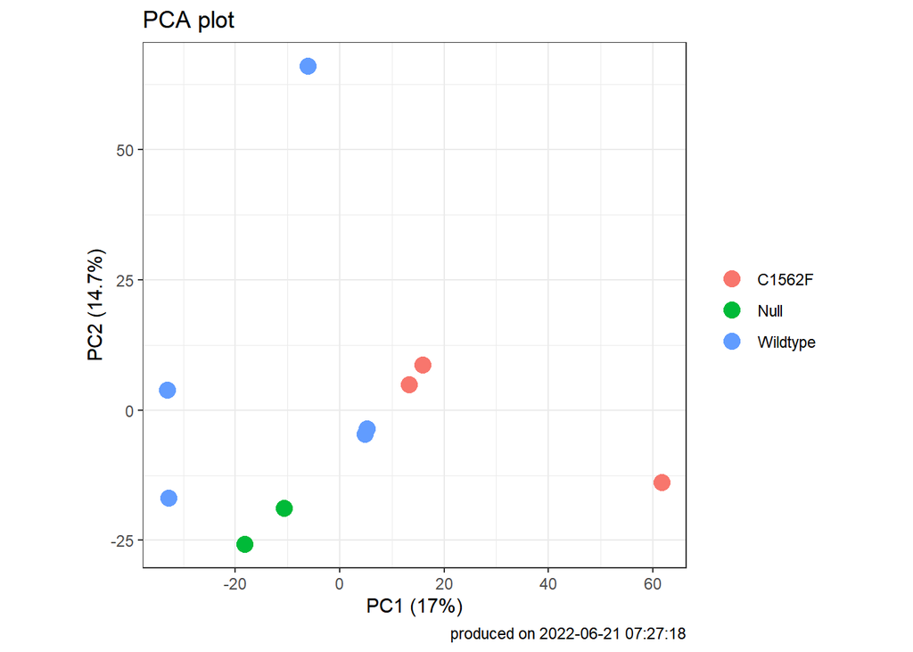

```r
group <- targets$group
group <- factor(group)
geno <- targets$geno
geno <- factor(geno)
geno_simp <- targets$geno_simp
geno_simp <- factor(geno_simp)

pca.res <- prcomp(t(log2.cpm.filtered.norm), scale.=F, retx=T)
pc.var<-pca.res$sdev^2 # sdev^2 captures these eigenvalues from the PCA result
pc.per<-round(pc.var/sum(pc.var)*100, 1)
pca.res.df <- as_tibble(pca.res$x)
pca.plot <- ggplot(pca.res.df) +
  aes(x=PC1, y=PC2, label=sampleLabels, color = geno_simp) +
  geom_point(size=4) +
  #stat_ellipse() +
  xlab(paste0("PC1 (",pc.per[1],"%",")")) +
  ylab(paste0("PC2 (",pc.per[2],"%",")")) +
  labs(title="PCA plot",
       caption=paste0("produced on ", Sys.time())) +
  coord_fixed() +
  theme_bw() +
  scale_color_discrete(name = NULL, labels = c("C1562F", "Null", "Wildtype"))

pca.plot
```

## 0.6 Volcano plot

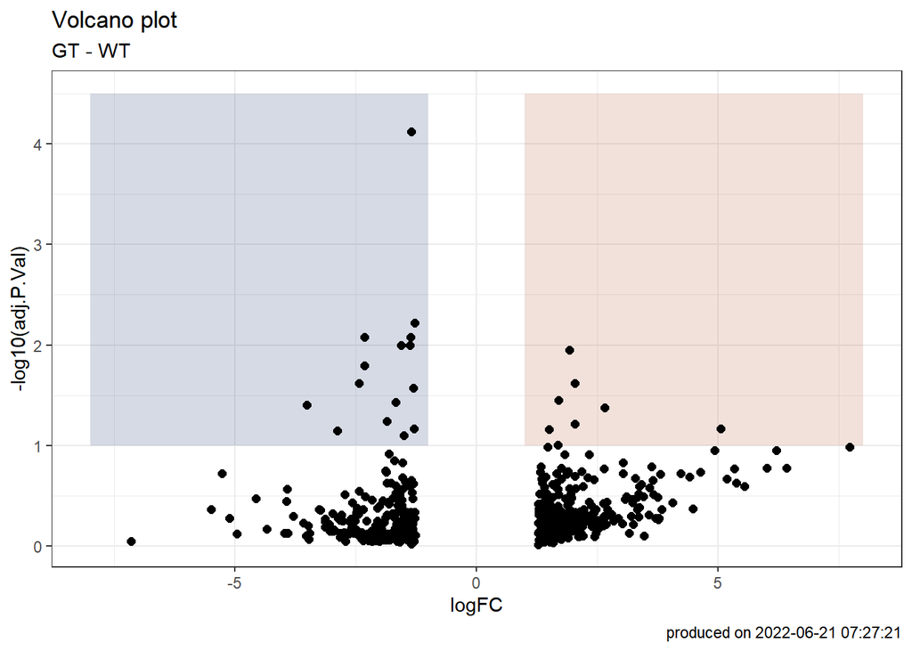

```r
library(tidyverse)
library(limma)
library(edgeR)
library(gt)
library(DT)
library(plotly)

geno_simp <- factor(targets$geno_simp)
geno_simp <- relevel(geno_simp, "wt") #sets reference level
design <- model.matrix(~ geno_simp +0)
colnames(design) <- levels(geno_simp)

v.DEGList.filtered.norm <- voom(myDGEList.filtered.norm, design, plot = FALSE)
fit <- lmFit(v.DEGList.filtered.norm, design)
contrast.matrix <- makeContrasts(ko = gt - wt,
                                 cf_ms = cf - wt,
                                 #gt_cf = gt - cf,
                                 levels=design)

fits <- contrasts.fit(fit, contrast.matrix)
ebFit <- eBayes(fits)

myTopHits1 <- topTable(ebFit, adjust ="BH", coef=1, number=500, sort.by="logFC")
myTopHits2 <- topTable(ebFit, adjust ="BH", coef=2, number=500, sort.by="logFC")


myTopHits1.df <- myTopHits1 %>%
  as_tibble(rownames = "geneID")
myTopHits2.df <- myTopHits2 %>%
  as_tibble(rownames = "geneID")


vplot1 <- ggplot(myTopHits1.df) +
  aes(y=-log10(adj.P.Val), x=logFC, text = paste("Symbol:", geneID)) +
  annotate("rect", xmin = 1, xmax = 8, ymin = -log10(0.1), ymax = 4.5, alpha=.2, fill="#BE684D") +
  annotate("rect", xmin = -1, xmax = -8, ymin = -log10(0.1), ymax = 4.5, alpha=.2, fill="#2C467A") +       geom_point(size=2) +
  labs(title="Volcano plot",
       subtitle = "GT - WT",
       caption=paste0("produced on ", Sys.time())) +
  theme_bw()

vplot1
```

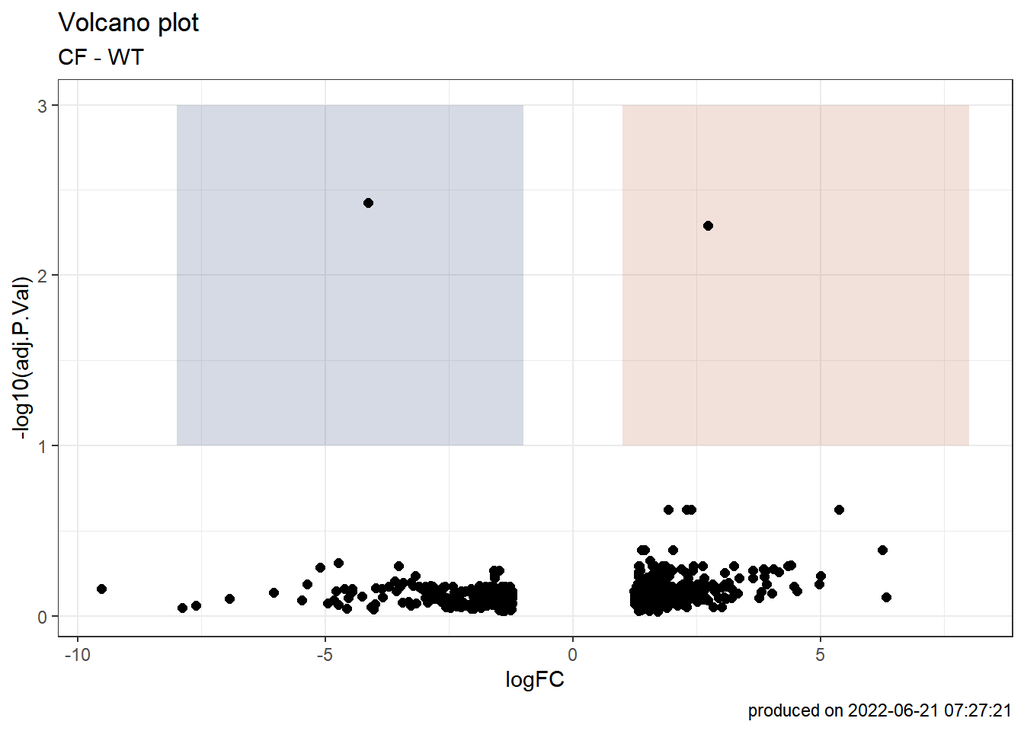

```r
vplot2 <- ggplot(myTopHits2.df) +
  aes(y=-log10(adj.P.Val), x=logFC, text = paste("Symbol:", geneID)) +
  annotate("rect", xmin = 1, xmax = 8, ymin = -log10(0.1), ymax = 3, alpha=.2, fill="#BE684D") +
  annotate("rect", xmin = -1, xmax = -8, ymin = -log10(0.1), ymax = 3, alpha=.2, fill="#2C467A") +
  geom_point(size=2) +
  labs(title="Volcano plot",
       subtitle = "CF - WT",
       caption=paste0("produced on ", Sys.time())) +
  theme_bw()

vplot2
```

## 0.7 Table of DEGs

```r
results <- decideTests(ebFit, method="global", adjust.method="BH", p.value=0.1, lfc=1.0)
colnames(v.DEGList.filtered.norm$E) <- sampleLabels
diffGenes <- v.DEGList.filtered.norm$E[results[,1] !=0 | results[,2] !=0,]
diffGenes.df <- as_tibble(diffGenes, rownames = "geneID")
datatable(diffGenes.df,
          extensions = c('KeyTable', "FixedHeader"),
          caption = 'Table 1: DEGs in Polr1a',
          options = list(keys = TRUE, searchHighlight = TRUE, pageLength = 10, lengthMenu = c("10", "25", "50", "100"))) %>%
  formatRound(columns=c(2:11), digits=2)
```

|  | geneID | Polr_2048_1 | Polr_2048_2 | Polr_2048_3 | Polr_2048_11 | Polr_2138_1 | Polr_2138_2 | Polr_2138_3 | Polr_2138_4 | Polr_2138_6 | Polr_2138_7 |
| --- | --- | --- | --- | --- | --- | --- | --- | --- | --- | --- | --- |
| 1 | 4930506M07Rik | 4.65263070000237 | 3.89737377021371 | 5.15595247693594 | 3.43990974243369 | 4.90034133080083 | 5.00667198924906 | 4.62959455018654 | 5.1175206581342 | 4.7130011896172 | 5.03082541050251 |
| 2 | Amd2 | 3.59915108743358 | 4.29188657790982 | 3.39622686143496 | 4.33183962688234 | 3.06486833316576 | 3.27846756202837 | 3.31033841976136 | 3.07457249634832 | 2.96053371894338 | 3.0898146080111 |
| 3 | Arl4d | 3.94342139931061 | 1.66177337190937 | 3.73805979743019 | 1.38926257509645 | 3.64203826048396 | 4.01250266147006 | 3.27454564271817 | 3.95051609283924 | 3.27051406559034 | 3.04910963810326 |
| 4 | Bcl11b | 7.58111074029652 | 7.00252851246779 | 7.88580046926239 | 6.54947767309269 | 7.93109695365076 | 8.12426109468398 | 7.6811843742063 | 8.07012312872737 | 7.46651703852425 | 7.60225887373634 |
| 5 | Bmper | 4.21968623219185 | 3.28309008710146 | 4.43417069583439 | 2.86192404887164 | 4.34047453078448 | 3.97930834251331 | 3.84858831939633 | 3.96701417714237 | 4.17842128961385 | 3.92828933635633 |
| 6 | C1qb | 2.94247867980042 | 3.99034271808165 | 2.41435691412599 | 4.04238032324906 | 2.72599707021862 | 2.71948797051906 | 3.6281333736154 | 3.25089962501342 | 3.4256543877929 | 3.92979490851387 |
| 7 | Ccng1 | 5.43259817058727 | 6.49952538205869 | 5.43334788057817 | 6.11878523559091 | 5.43533475586384 | 5.82428764271183 | 6.53335676946761 | 5.35288492466609 | 6.50262935318647 | 6.4449498751713 |
| 8 | Cdkn1a | 4.07673467240385 | 5.21517666945142 | 3.65373419825704 | 4.48187527650441 | 4.10730223363959 | 3.64110533206049 | 4.99018135701162 | 4.20015303275285 | 4.88918720737081 | 5.04231540971494 |
| 9 | Dhx30 | 3.32930798767061 | 5.37130287862097 | 4.24159921080588 | 5.63102285852247 | 1.26295194806141 | 2.11534009894386 | 4.093078568357 | 3.26537223107507 | 4.65457138240478 | 5.41966894913966 |
| 10 | Dkk2 | 4.47380936185935 | 5.12734098209368 | 3.92984288230083 | 5.41604320135833 | 4.40296224111692 | 4.02309144259739 | 4.75086755618698 | 4.54306702428829 | 4.87751709142655 | 5.06093208403817 |

[output cut: 35 more lines]

```r
#write.csv(diffGenes.df, "diffGenes.csv")
```

## 0.8 Heatmaps and modules

Pearson correlation was used to cluster **45** differentially expressed genes, which were then represented as heatmap with the data scaled by Zscore for each row. The first heatmap shows all differentially expressed genes, and the following heatmaps show each module. The last module is not shown, as it is only one gene, Rpl34.

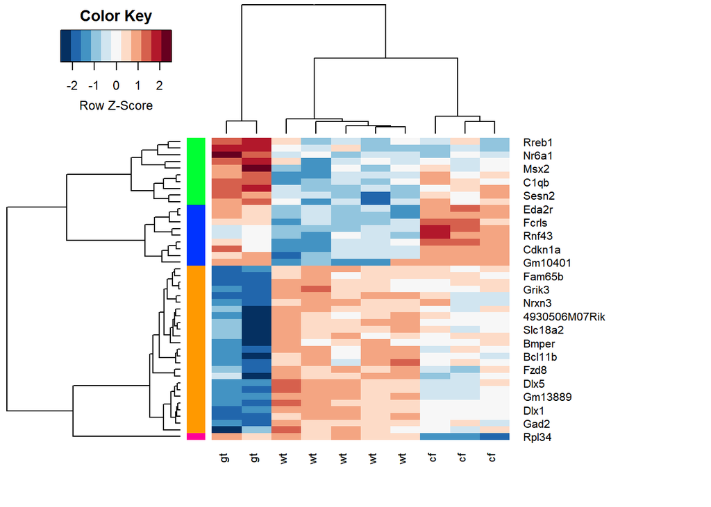

```r
library(tidyverse)
library(gplots)
library(RColorBrewer)
library(ggplot2)

myheatcolors <- rev(brewer.pal(name="RdBu", n=11))
colnames(diffGenes) <- targets$geno_simp #Change names to geno_simp
clustRows <- hclust(as.dist(1-cor(t(diffGenes), method="pearson")), method="complete") #cluster rows by pearson correlation
clustColumns <- hclust(as.dist(1-cor(diffGenes, method="spearman")), method="complete")
module.assign <- cutree(clustRows, k=4)
module.color <- rainbow(length(unique(module.assign)), start=0.1, end=0.9)
module.color <- module.color[as.vector(module.assign)]
heatmap.2(diffGenes,
          Rowv=as.dendrogram(clustRows),
          Colv=as.dendrogram(clustColumns),
          RowSideColors=module.color,
          col=myheatcolors, scale='row',
          #labRow=NA, #remove labRow argument for gene labels
          density.info="none", trace="none",
          cexRow=1, cexCol=1, margins=c(5,15))
```

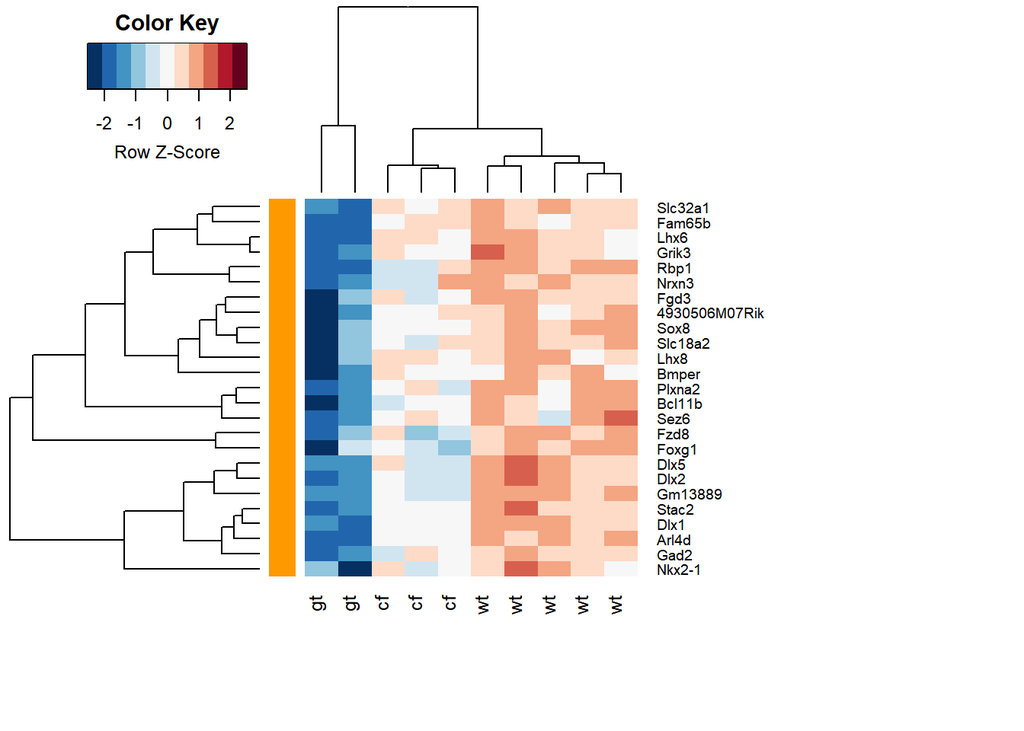

```r
modulePick1 <- 1
myModule1 <- diffGenes[names(module.assign[module.assign %in% modulePick1]),]
hrsub1 <- hclust(as.dist(1-cor(t(myModule1), method="pearson")), method="complete")

modulePick2 <- 2
myModule2 <- diffGenes[names(module.assign[module.assign %in% modulePick2]),]
hrsub2 <- hclust(as.dist(1-cor(t(myModule2), method="pearson")), method="complete")

modulePick3 <- 3
myModule3 <- diffGenes[names(module.assign[module.assign %in% modulePick3]),]
hrsub3 <- hclust(as.dist(1-cor(t(myModule3), method="pearson")), method="complete")

modulePick4 <- 4
myModule4 <- diffGenes[names(module.assign[module.assign %in% modulePick4]),]
myModule4 <- t(myModule4)
rownames(myModule4) = c("Rpl34")

h1 <- heatmap.2(myModule1,
          Rowv=as.dendrogram(hrsub1),
          col=myheatcolors, scale="row",
          density.info="none", trace="none",
          RowSideColors=module.color[module.assign%in%modulePick1], margins=c(8,20))
```

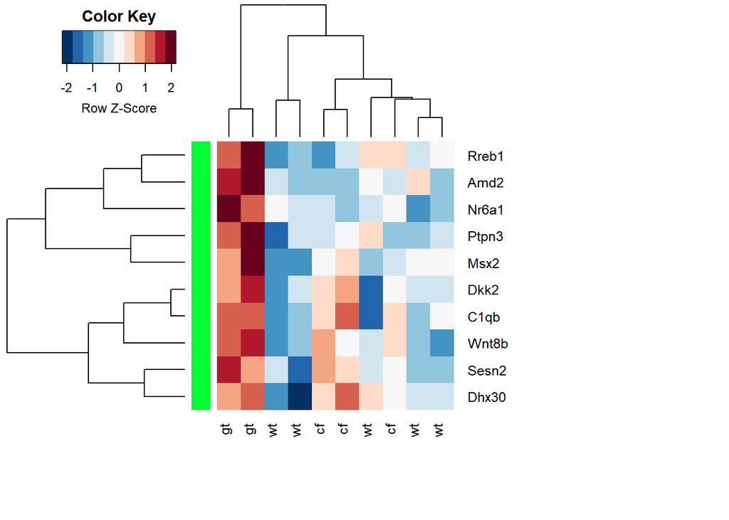

```r
h2 <- heatmap.2(myModule2,
          Rowv=as.dendrogram(hrsub2),
          col=myheatcolors, scale="row",
          density.info="none", trace="none",
          RowSideColors=module.color[module.assign%in%modulePick2], margins=c(8,20))
```

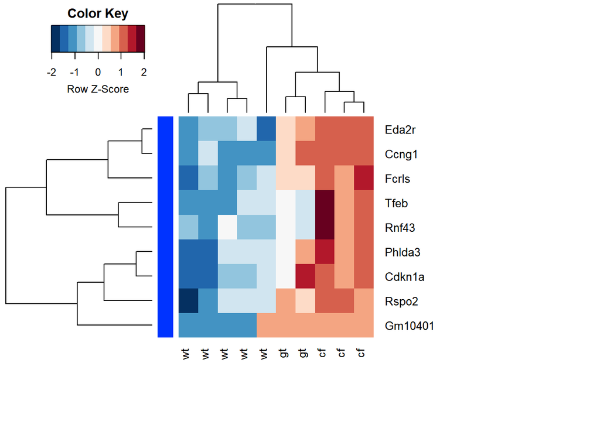

```r
h3 <- heatmap.2(myModule3,
          Rowv=as.dendrogram(hrsub3),
          col=myheatcolors, scale="row",
          density.info="none", trace="none",
          RowSideColors=module.color[module.assign%in%modulePick3], margins=c(8,20))
```

## 0.9 GO enrichment

GO enrichment for differentially expressed genes was completed using [gprofiler2](https://doi.org/10.12688/f1000research.24956.2). The following gostplots are shown in the same order as the module heatmaps above. The last module, containing Rpl34, is also shown. final bubbleplot contains selected GO terms for each genotype.

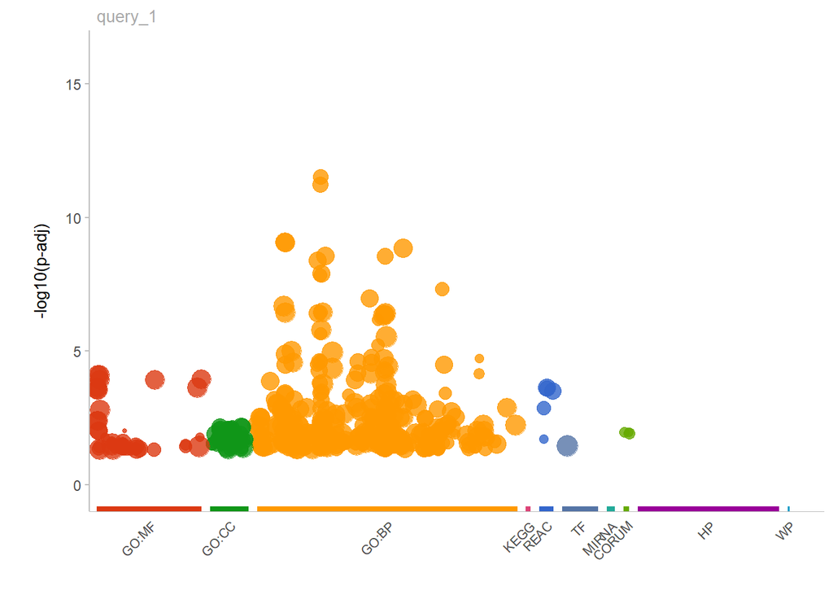

```r
library(tidyverse)
library(gplots) #for heatmaps
library(gprofiler2) #tools for accessing the GO enrichment results using g:Profiler web resources
#You need this package "Patchwork" from https://github.com/thomasp85/patchwork , there is another Patchwork package that will not work with the following packages, and it may be installed by them, by mistake.

gost.res_up1 <- gost(rownames(myModule1), organism = "mmusculus", correction_method = "fdr")
gostplot(gost.res_up1, interactive = F, capped = F) #set interactive=TRUE to see each GO term
```

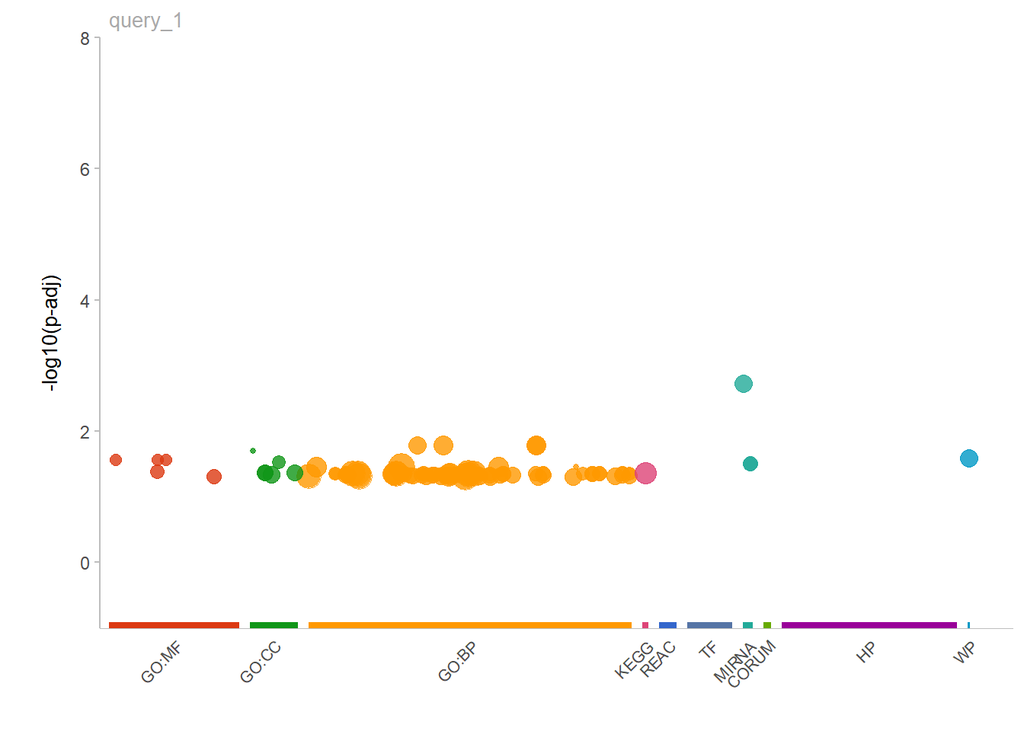

```r
gost.res_up2 <- gost(rownames(myModule2), organism = "mmusculus", correction_method = "fdr")
gostplot(gost.res_up2, interactive = F, capped = F) #set interactive=TRUE to see each GO term
```

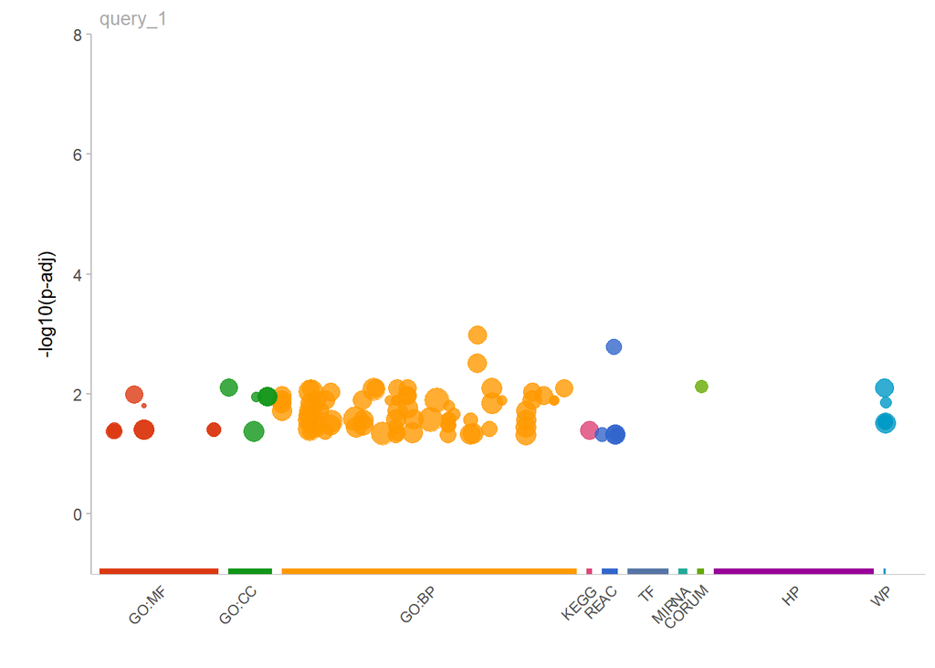

```r
gost.res_up3 <- gost(rownames(myModule3), organism = "mmusculus", correction_method = "fdr")
gostplot(gost.res_up3, interactive = F, capped = F) #set interactive=TRUE to see each GO term
```

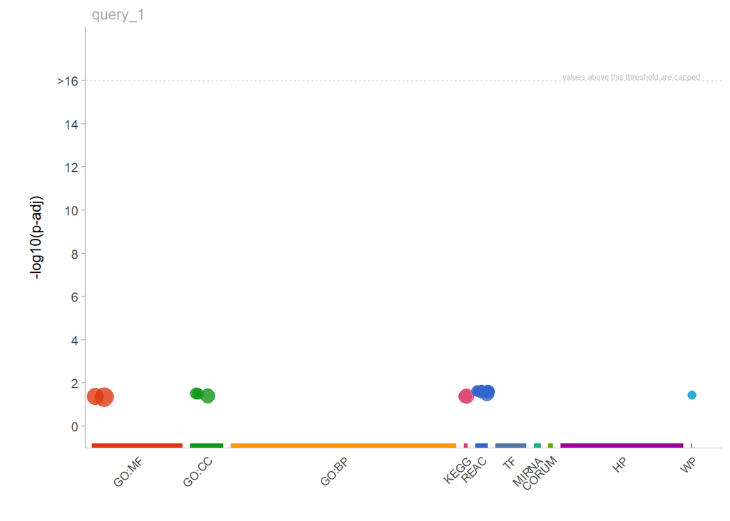

```r
gost.res_up4 <- gost(rownames(myModule4), organism = "mmusculus", correction_method = "fdr")
gostplot(gost.res_up4, interactive = F, capped = T) #set interactive=TRUE to see each GO term
```

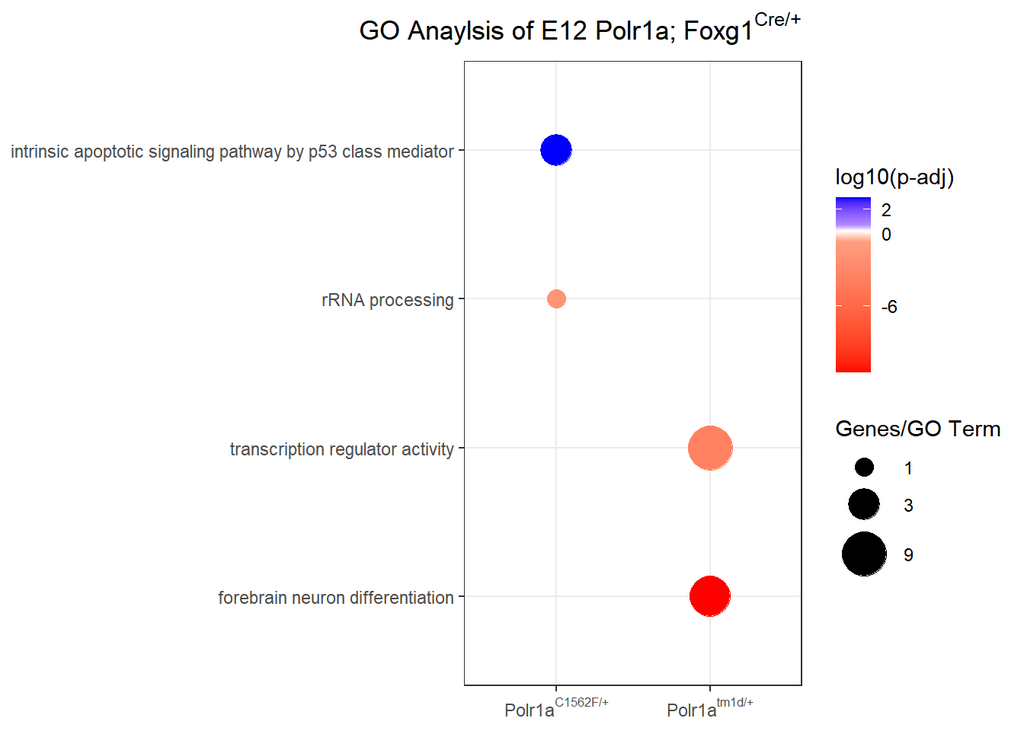

```r
gtdown.datatable <- gost.res_up1$result %>%
  mutate(geno = "gt", change = "down")

gtup.datatable <- gost.res_up2$result %>%
  mutate(geno = "gt", change = "up")

cfdown.datatable <- gost.res_up4$result %>%
  mutate(geno = "cf", change = "down")

cfup.datatable <- gost.res_up3$result %>%
  mutate(geno = "cf", change = "up")

all.datatable <- bind_rows(gtup.datatable, gtdown.datatable, cfup.datatable, cfdown.datatable, id = NULL)

selected <- c("GO:0021879", "GO:0140110", "GO:0072332","REAC:R-MMU-72312")

select.table <- filter(all.datatable, term_id %in% selected) %>%
  mutate(log_pv = case_when(
    change == "down"  ~ log10(p_value),
    change == "up"    ~ -(log10(p_value)))) %>%
  mutate(term_name = fct_reorder(term_name, log_pv))

ggplot(select.table) +
  geom_point(aes(x = geno, y = term_name, size = intersection_size, color = log_pv)) +
  scale_colour_gradientn(breaks = c(2, 0, -6, -12),  labels = c(2, 0, -6, -12), name = "log10(p-adj)", colours = c("blue", "white", "red"), values = scales::rescale(c(3, 0.5, 0, -1.0, -13))) +
  scale_size(breaks = c(1, 3, 9), range = c(4, 10), name = "Genes/GO Term") +
  labs(y = NULL, title = bquote(paste("GO Anaylsis of E12 Polr1a;"~"Foxg1"^"Cre/+"))) +
  scale_x_discrete(name = NULL, labels = c(bquote(paste("Polr1a"^"C1562F/+")), bquote(paste("Polr1a"^"tm1d/+")))) +
  theme_bw() +
  theme(plot.title = element_text(hjust = 1))
```

Heatmaps of Selected GO Enrichment terms

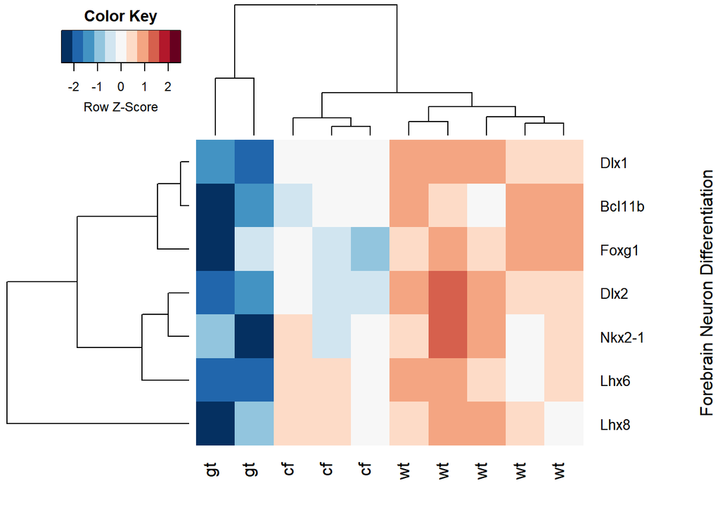

```r
library(tidyverse)
library(RColorBrewer)
library(gplots)
library(stringr)
library(patchwork)

myheatcolors <- rev(brewer.pal(name="RdBu", n=11))

gene_order <- c("Bcl11b", "Dlx1", "Dlx2", "Foxg1",
                          "Lhx6", "Lhx8", "Nkx2-1",
                          "Dlx5", "Slc32a1", "Sox8", "Cdkn1a",
                          "Eda2r", "Phlda3", "Ccng1", "Rpl34")

select.instersection <- filter(diffGenes.df, geneID %in% c("Bcl11b", "Dlx1", "Dlx2", "Foxg1",
                                                           "Lhx6", "Lhx8", "Nkx2-1",
                                                           "Dlx5", "Slc32a1", "Sox8", "Cdkn1a",
                                                           "Eda2r", "Phlda3", "Ccng1", "Rpl34")) %>%
  arrange(factor(geneID, levels = c("Bcl11b", "Dlx1", "Dlx2", "Foxg1",
                                              "Lhx6", "Lhx8", "Nkx2-1",
                                              "Dlx5", "Slc32a1", "Sox8", "Cdkn1a",
                                              "Eda2r", "Phlda3", "Ccng1", "Rpl34"))) %>%
  data.frame(row.names = 1)

hmall <- as.matrix(select.instersection)
colnames(hmall) <- targets$geno_simp


hm1 <- filter(select.instersection, row.names(select.instersection) %in% c("Bcl11b","Dlx1","Dlx2","Foxg1","Lhx6","Lhx8","Nkx2-1")) %>%
  as.matrix()
colnames(hm1) <- targets$geno_simp


hm2 <- filter(select.instersection, row.names(select.instersection) %in% c("Bcl11b","Dlx1","Dlx2","Dlx5","Foxg1","Lhx6","Nkx2-1","Slc32a1")) %>%
  as.matrix()
colnames(hm2) <- targets$geno_simp


hm3 <- filter(select.instersection, row.names(select.instersection) %in% c("Bcl11b","Dlx1","Dlx2","Dlx5","Foxg1","Lhx6","Lhx8","Nkx2-1","Sox8")) %>%
  as.matrix()
colnames(hm3) <- targets$geno_simp


hm4 <- filter(select.instersection, row.names(select.instersection) %in% c("Cdkn1a","Eda2r","Phlda3")) %>%
  as.matrix()
colnames(hm4) <- targets$geno_simp


hm5 <- filter(select.instersection, row.names(select.instersection) %in% c("Ccng1","Cdkn1a")) %>%
  as.matrix()
colnames(hm5) <- targets$geno_simp



hm1map <- heatmap.2(hm1,
          col=myheatcolors, scale="row",
          density.info="none", trace="none",
          margins=c(4,8),
          rowsep = c(),
          ylab = "Forebrain Neuron Differentiation",
          cexRow = 1.0
          )
```

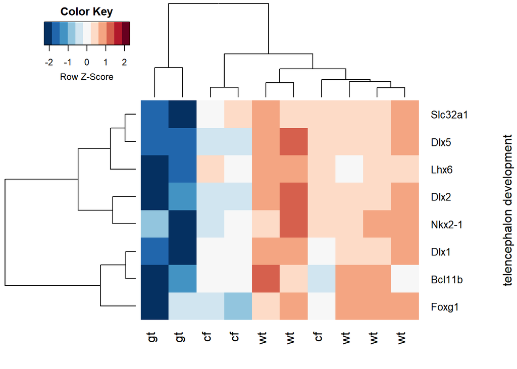

```r
hm2map <- heatmap.2(hm2,
                    col=myheatcolors, scale="row",
                    density.info="none", trace="none",
                    margins=c(4,8),
                    rowsep = c(),
                    ylab = "telencephalon development",
                    cexRow = 1.0
                    )
```

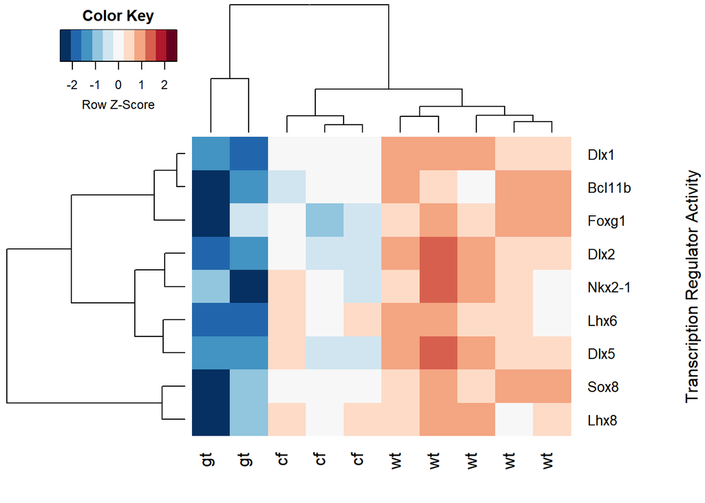

```r
hm3map <- heatmap.2(hm3,
                    col=myheatcolors, scale="row",
                    density.info="none", trace="none",
                    margins=c(4,8),
                    rowsep = c(),
                    ylab = "Transcription Regulator Activity",
                    cexRow = 1.0
                    )
```

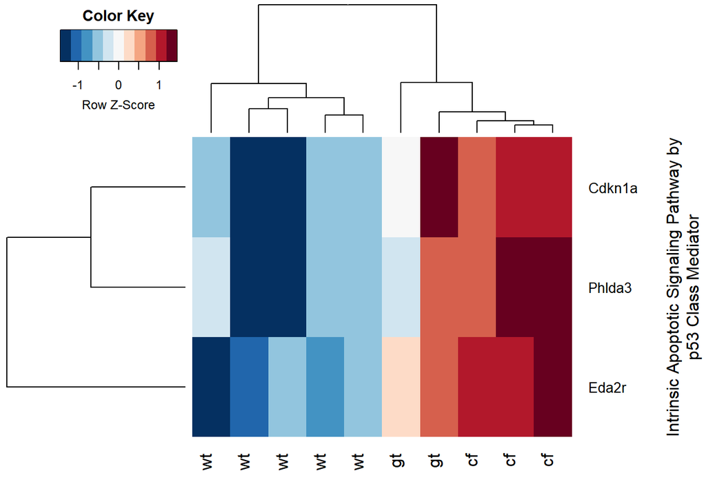

```r
hm4map <- heatmap.2(hm4,
                    col=myheatcolors, scale="row",
                    density.info="none", trace="none",
                    margins=c(4,8),
                    rowsep = c(),
                    ylab = str_wrap("Intrinsic Apoptotic Signaling Pathway by p53 Class Mediator", width = 40),
                    cexRow = 1.0
                    )
```

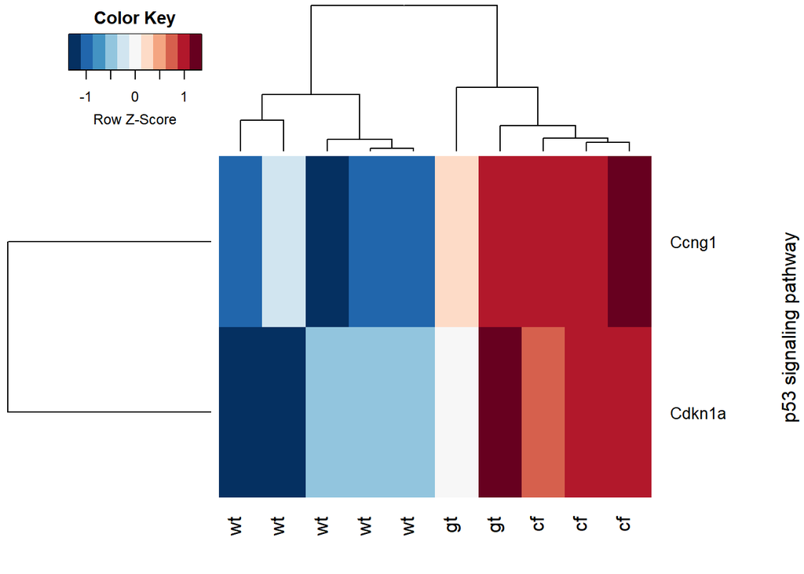

```r
hm5map <- heatmap.2(hm5,
                    col=myheatcolors, scale="row",
                    density.info="none", trace="none",
                    margins=c(4,8),
                    rowsep = c(),
                    ylab = "p53 signaling pathway",
                    cexRow = 1.0
                    )
```

## 0.10 Session info

The following output details all packages, with versions, used to reproduce the results of this report.

[session information not shown]